# R Notebook

1 MVP Now we’ll go back to CI creation in the normal fashion. We’ll take the ames data from the CIs lab earlier today and regard it now as a sample, we won’t be drawing any smaller samples from within it. This is the usual situation in an analysis: you use all the data available to you!

```r
library(tidyverse)
library(infer)
library(janitor)
```

Task 1. Load the data again, clean_names(), and re-familiarise yourself with it

```r
ames <- read_csv("data/ames.csv") %>% clean_names()
```

Task 2. Investigate the distribution of lot_area. Is the distribution roughly normal? If not, what problems do you find?

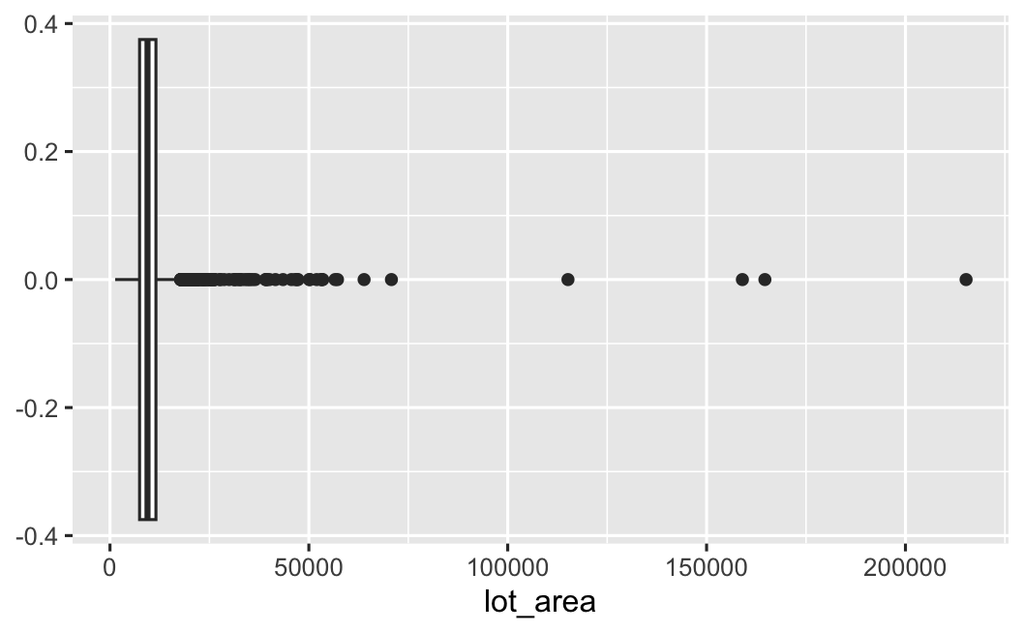

```r
ames %>%
  ggplot(aes(x = lot_area)) +
  geom_boxplot()
```

```r
NA
NA
```

very skewed, lots of outlieres

Task 3. Compute and visualise a bootstrap sampling distribution for the mean(lot_area) of the sold houses.

```r
ames %>%
  specify(response = lot_area) %>%
  generate(reps = 5000, type = "bootstrap") %>%
  calculate(stat = "mean")
```

```
Response: lot_area (numeric)
```

| replicate | stat |
| --- | --- |
| 1 | 9988.142 |
| 2 | 10013.568 |
| 3 | 10193.243 |
| 4 | 10137.655 |
| 5 | 10022.262 |
| 6 | 9852.140 |
| 7 | 10130.891 |
| 8 | 10011.557 |
| 9 | 10185.103 |
| 10 | 10116.144 |

[output cut: 990 more lines]

Task 4. Use your bootstrap distribution to calculate a 95% CI for mean(lot_area), and visualise it on the distribution

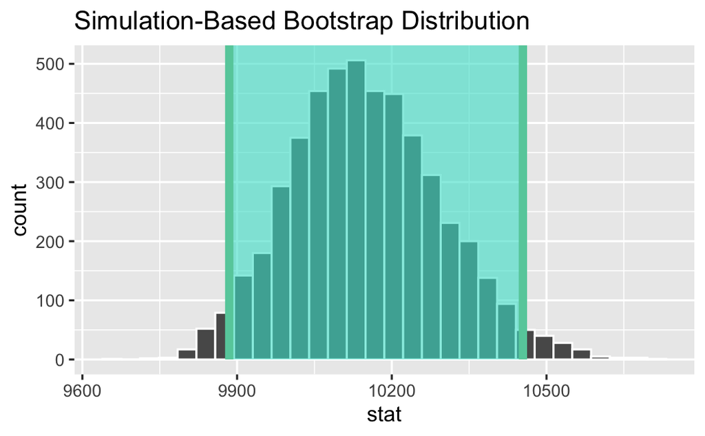

```r
infer_ci <- infer_ames %>%
  get_ci(level = 0.95, type = "percentile")

infer_ames %>%
  visualise(bins = 30) +
  shade_ci(endpoints = infer_ci)
```

Task 5. You would like to know the mean(lot_area) of the sold houses with higher confidence. Calculate the 99% CI for this variable (you can re-use your bootstrap distribution from above). Is it narrower or broader than the 95% CI? Does that make sense?

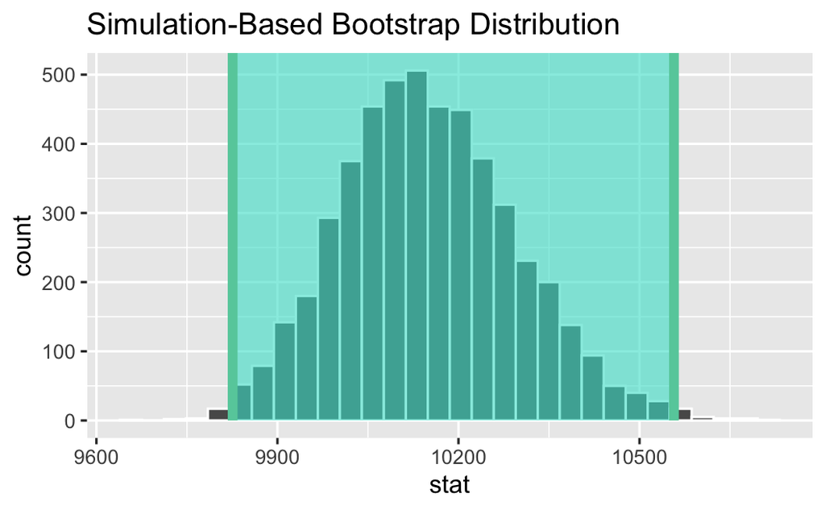

```r
infer_ci_99 <- infer_ames %>%
  get_ci(level = 0.99, type = "percentile")

infer_ames %>%
  visualise(bins = 30) +
  shade_ci(endpoints = infer_ci_99)
```

```r
NA
NA
```

the 99% is broder = as the CI for 95% is [99,105] when 99% [98,106] 99% is cap more data

Task 6. Calculate the point estimate of the mean(lot_area)

| mean |
| --- |
| 10150.58 |

mean = 10150.58

2 Extension

Task 1. Calculate a point estimate and 95% CI for the proportion of houses in the data built before 1920. Does the number of reps you use matter? [Investigate reps from 200 up to 50000 , memory of your laptop permitting].

| order | pid | ms_sub_class | ms_zoning | lot_frontage | lot_area | street | alley | lot_shape | land_contour | utilities | lot_config | land_slope | neighborhood | condition_1 | condition_2 | bldg_type | house_style | overall_qual | overall_cond | before_1920 | year_built | year_remod_add | roof_style | roof_matl | exterior_1st | exterior_2nd | mas_vnr_type | mas_vnr_area | exter_qual | … |
| --- | --- | --- | --- | --- | --- | --- | --- | --- | --- | --- | --- | --- | --- | --- | --- | --- | --- | --- | --- | --- | --- | --- | --- | --- | --- | --- | --- | --- | --- | --- |
| 1 | 526301100 | 20 | RL | 141 | 31770 | Pave | NA | IR1 | Lvl | AllPub | Corner | Gtl | NAmes | Norm | Norm | 1Fam | 1Story | 6 | 5 | No | 1960 | 1960 | Hip | CompShg | BrkFace | Plywood | Stone | 112 | TA | … |
| 2 | 526350040 | 20 | RH | 80 | 11622 | Pave | NA | Reg | Lvl | AllPub | Inside | Gtl | NAmes | Feedr | Norm | 1Fam | 1Story | 5 | 6 | No | 1961 | 1961 | Gable | CompShg | VinylSd | VinylSd | None | 0 | TA | … |
| 3 | 526351010 | 20 | RL | 81 | 14267 | Pave | NA | IR1 | Lvl | AllPub | Corner | Gtl | NAmes | Norm | Norm | 1Fam | 1Story | 6 | 6 | No | 1958 | 1958 | Hip | CompShg | Wd Sdng | Wd Sdng | BrkFace | 108 | TA | … |
| 4 | 526353030 | 20 | RL | 93 | 11160 | Pave | NA | Reg | Lvl | AllPub | Corner | Gtl | NAmes | Norm | Norm | 1Fam | 1Story | 7 | 5 | No | 1968 | 1968 | Hip | CompShg | BrkFace | BrkFace | None | 0 | Gd | … |
| 5 | 527105010 | 60 | RL | 74 | 13830 | Pave | NA | IR1 | Lvl | AllPub | Inside | Gtl | Gilbert | Norm | Norm | 1Fam | 2Story | 5 | 5 | No | 1997 | 1998 | Gable | CompShg | VinylSd | VinylSd | None | 0 | TA | … |
| 6 | 527105030 | 60 | RL | 78 | 9978 | Pave | NA | IR1 | Lvl | AllPub | Inside | Gtl | Gilbert | Norm | Norm | 1Fam | 2Story | 6 | 6 | No | 1998 | 1998 | Gable | CompShg | VinylSd | VinylSd | BrkFace | 20 | TA | … |
| 7 | 527127150 | 120 | RL | 41 | 4920 | Pave | NA | Reg | Lvl | AllPub | Inside | Gtl | StoneBr | Norm | Norm | TwnhsE | 1Story | 8 | 5 | No | 2001 | 2001 | Gable | CompShg | CemntBd | CmentBd | None | 0 | Gd | … |
| 8 | 527145080 | 120 | RL | 43 | 5005 | Pave | NA | IR1 | HLS | AllPub | Inside | Gtl | StoneBr | Norm | Norm | TwnhsE | 1Story | 8 | 5 | No | 1992 | 1992 | Gable | CompShg | HdBoard | HdBoard | None | 0 | Gd | … |
| 9 | 527146030 | 120 | RL | 39 | 5389 | Pave | NA | IR1 | Lvl | AllPub | Inside | Gtl | StoneBr | Norm | Norm | TwnhsE | 1Story | 8 | 5 | No | 1995 | 1996 | Gable | CompShg | CemntBd | CmentBd | None | 0 | Gd | … |
| 10 | 527162130 | 60 | RL | 60 | 7500 | Pave | NA | Reg | Lvl | AllPub | Inside | Gtl | Gilbert | Norm | Norm | 1Fam | 2Story | 7 | 5 | No | 1999 | 1999 | Gable | CompShg | VinylSd | VinylSd | None | 0 | TA | … |

[output cut: 990 more lines]

```r
ames%>%
  specify(response = before_1920, success ="Yes") %>%
  generate(reps = 5000, type = "bootstrap") %>%
  calculate(stat = "prop")
```

```
Response: before_1920 (factor)
```

| replicate | stat |
| --- | --- |
| 1 | 0.05972696 |
| 2 | 0.05802048 |
| 3 | 0.05290102 |
| 4 | 0.05290102 |
| 5 | 0.05699659 |
| 6 | 0.04539249 |
| 7 | 0.05221843 |
| 8 | 0.04470990 |
| 9 | 0.05153584 |
| 10 | 0.05017065 |

[output cut: 990 more lines]

| lower_ci | upper_ci |
| --- | --- |
| 0.04334471 | 0.05904437 |

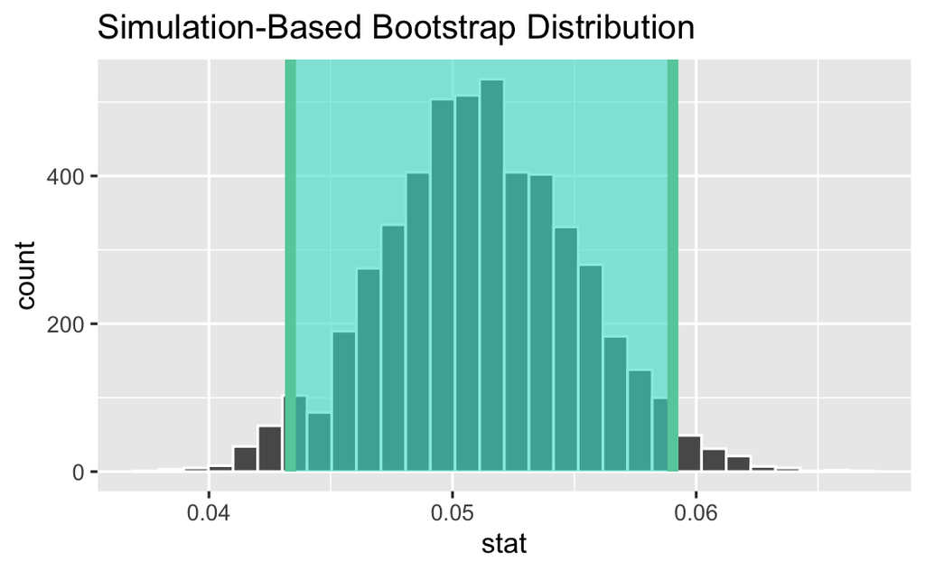